# An Analysis of the Veteran Survival Dataset

Author

Cameron-Scott Sommerville

Kalbfleisch & Prentice (1980) produced a dataset from a longitudinal clinical study on military veterans with terminal lung cancer with treatments across two conditions: standard therapy versus test chemotherapy, with participant allocation randomised. The variables observed within this dataset are:

- Treatment type
- Cell type
- Survival time
- Status (censoring)
- Karnofsky performance score (health index)
- Months from diagnosis
- Prior therapy

# Packages Used

This data has been obtained by way of the `survival` package created by Terry M. Therneau and Patricia M. Grambsch (2000).

Other packages used throughout the course of this document are `tidyverse (v. 2.0.0)`, `ggsurvfit (v. 1.2.1)`, `survminer`, and `patchwork (v. 1.3.2)`.

The primary research question regarding this dataset is, “does the novel chemotherapy treatment result in better survival outcomes than the standard therapy treatment”?

# Visualising the Data

First, let’s look at what the dataset actually contains. Reading the data off a table is a very wearisome task, so let’s translate it into a visual graph instead.

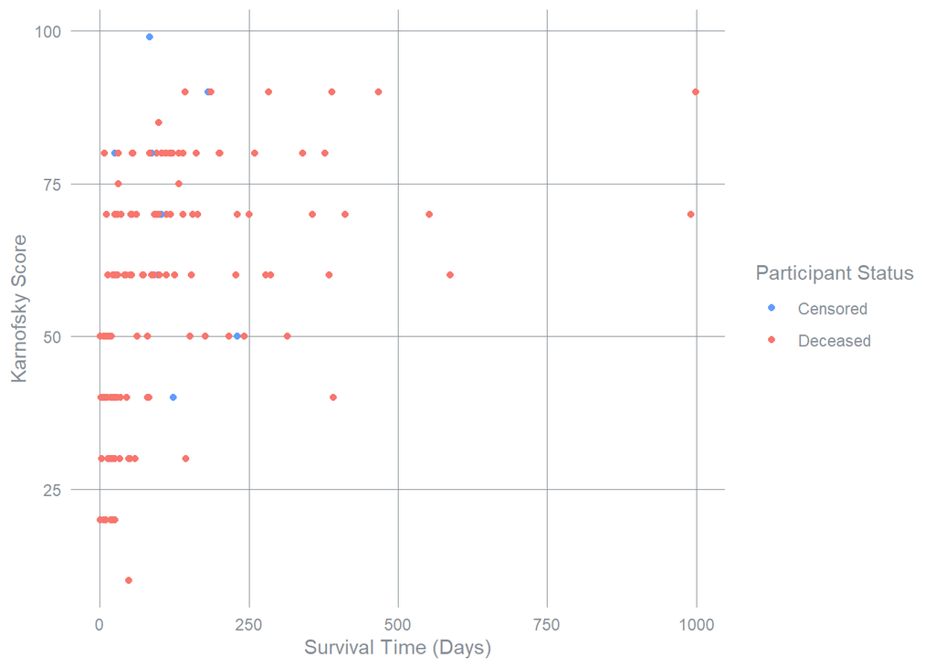

Figure 1: A rough overview of the relationship between time and Karnofsky scoring. A lower score typically means worse health, higher scores mean better health. Points are colour-coded by status, either deceased or censored. Note, ‘censored’ does not mean ‘alive’, rather it means the researchers stopped observing and have no further information regarding status.

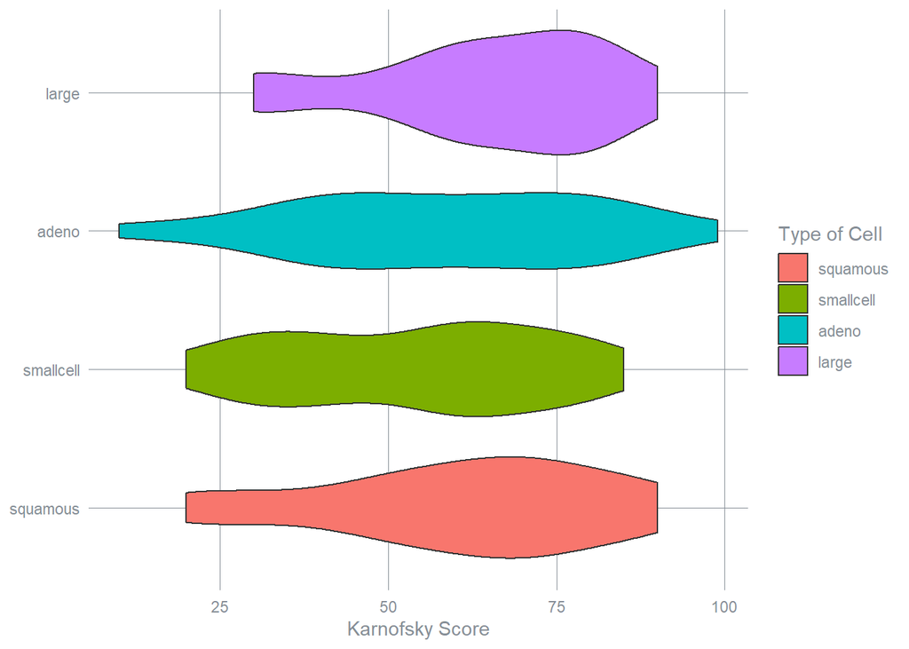

Figure 2: Violin density plot of Karnofsky health index scores by cancer cell type. Wider portions denote higher density (i.e., more data points within that interval).

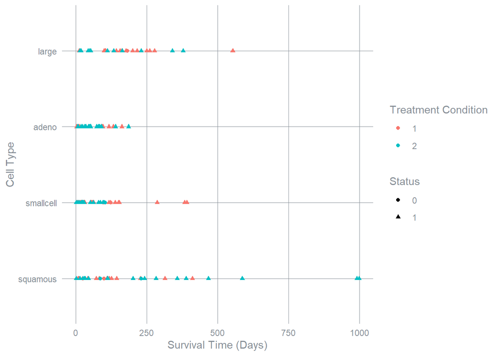

Figure 3: Dot plot comparing cell type against survival time (in days), colour coded by treatment condition, shape coded by patient status upon study end.

Here we can see the distribution of points based on cell type and survival time, colour-coded by treatment condition. Visually, one can see there isn’t much apparent difference between survival times across conditions within the top three cell types, with only squamous cells indicating any potentially significant difference in treatment outcome. This begs the question whether or not treatment is actually effectuating that difference, or whether this is a natural consequence of the cancer cell type itself.

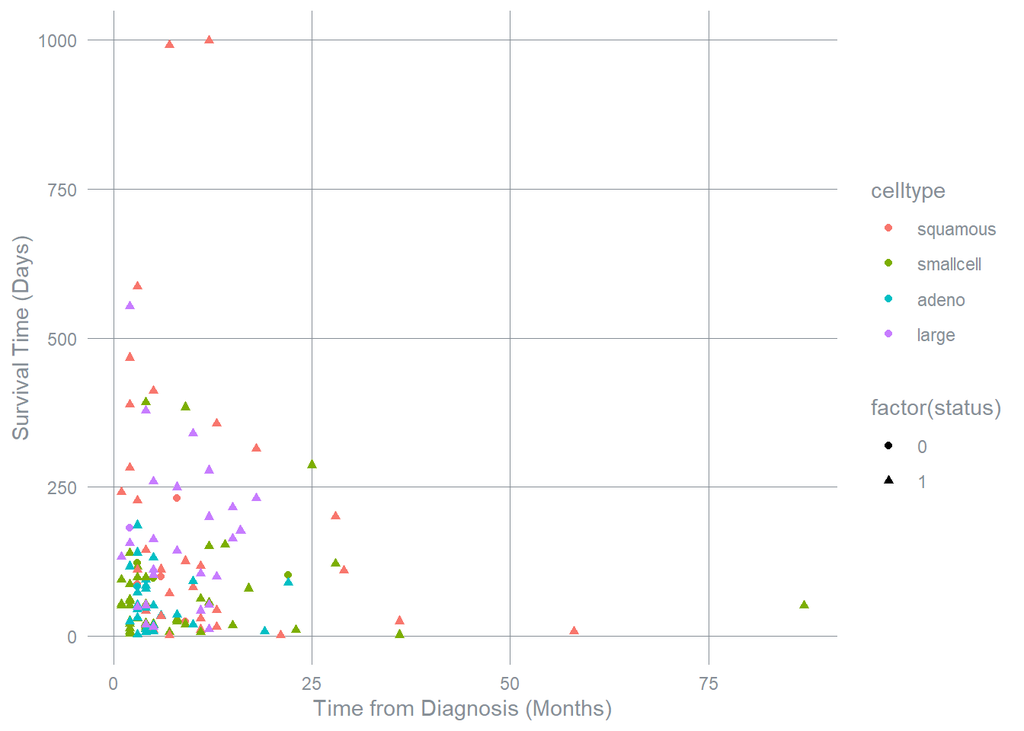

Figure 4: Comparison of time from diagnosis (in months) against recorded survival time (in days). Colour-coded by cell type and shape coded by patient status upon study end.

The final thing we’re visualising here is the time from initial cancer diagnosis against survival time. At a quick glance, most points are centred around the bottom left corner of the graph, indicating both a low time from diagnosis and low survival time. Each point is colour-coded according to the type of cancer the individual has, with small-cell and adenocarcinoma cells dominating casualty-counts in the bottom left quadrant of the graph. By comparison, squamous - and to some extent large cell cancers - seem to have a slightly more diffuse distribution, with the two longest-surviving patients both having squamous-cell type lung cancer.

This makes sense, existing literature states that adenocarcinoma cells (e.g., glandular cells that are typically involved in the production of mucus substances) are often only detected in advanced stages typically resulting in shorter survival times (Kanchustambham and Sharma 2026).

# Statistical Analyses

## Assumptions

The analysis in this document operates off of the following assumptions:

- Censored patients have the same survival prospects as non-censored patients (i.e., censoring is not taking place in anticipation of the event)
- Survival probabilities remain the same across the span of the study (e.g., no change in quality of care)
- Event timing remains precise, not lumped together in wide intervals
- All survival observations remain independent (e.g., the survival of patient A does not impact the survival of patient B)
- All events (deaths) come from the same standard cause, and not from a competing risk (e.g., all deaths herein are from cancer, not extraneous causes like car crashes, falls, etcetera)

As there is no way to verify this beyond trusting the initial researchers, we shall trust that these assumptions are met.

## Naive Kaplan-Meier Plot

The first thing one can do to address the question of treatment effects on survival time outcomes is to create a Kaplan-Meier plot comparing treatment condition to survival outcomes.

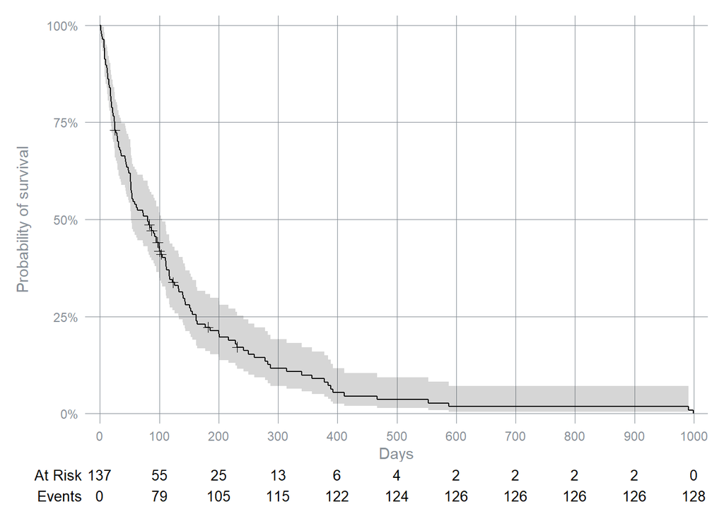

Figure 5: The probability of survival (Y-axis) against the total time in days (X-axis) for the entire cohort across all cell types and all treatment conditions. Grey area surrounding the KM line denotes the confidence interval. Risk table at the bottom shows how many participants are still being followed and are either free of the event, or have been censored, or have had the event occur. Cross marks on the line denote cases of censoring. N = 137

### Treatment-type differences

We can plot the difference in survival between treatment conditions like so.

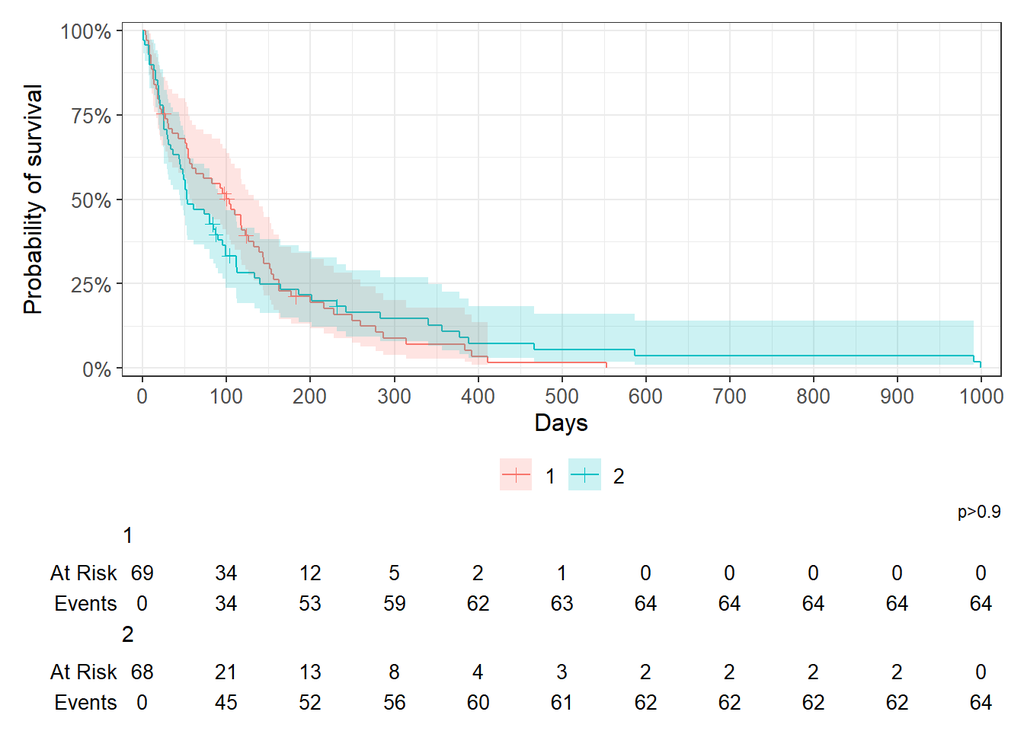

Figure 6: The probability of survival (Y-axis) against the total time in days (X-axis) for the entire cohort across all cell types, segregated by treatment condition (1 = normal chemotherapy, 2 = experimental). Coloured area surrounding the KM line denotes the confidence interval. Risk table at the bottom shows how many participants are still being followed and are either free of the event, or have been censored, or have had the event occur. Cross marks on the line denote cases of censoring. Total N = 137, condition 1 N = 69, condition 2 N = 68.

The plot above shows that the survival curves for each condition appear strikingly similar, and we also see that the difference between the two curves is not statistically significant (*p*>0.9). This plot of course does not look at the differences between cell types, and thus does not take into account the possibility that the treatment affects the physiologies of each type of cancer differently.

We can run a final log-rank test using the treatment conditions alone to double-check the significance result.

```r
log_rank_trtdiff <- survdiff(Surv(time, status) ~ trt, data = veteran_data_df)
log_rank_trtdiff
```

```
Call:
survdiff(formula = Surv(time, status) ~ trt, data = veteran_data_df)

       N Observed Expected (O-E)^2/E (O-E)^2/V
trt=1 69       64     64.5   0.00388   0.00823
trt=2 68       64     63.5   0.00394   0.00823

 Chisq= 0  on 1 degrees of freedom, p= 0.9
```

As one can see, there is still no significant difference between naive treatment condition alone. With that, we can move onto the impact cell type may have on survival probability.

### Cell-type differences

There are four distinct cancer cell types in this dataset:

1. Squamous cells
2. Small cells
3. Adenocarcinoma cells
4. Large cells

Below one can see a plot of the differences in survival probability across both treatment conditions, segregated by cell type.

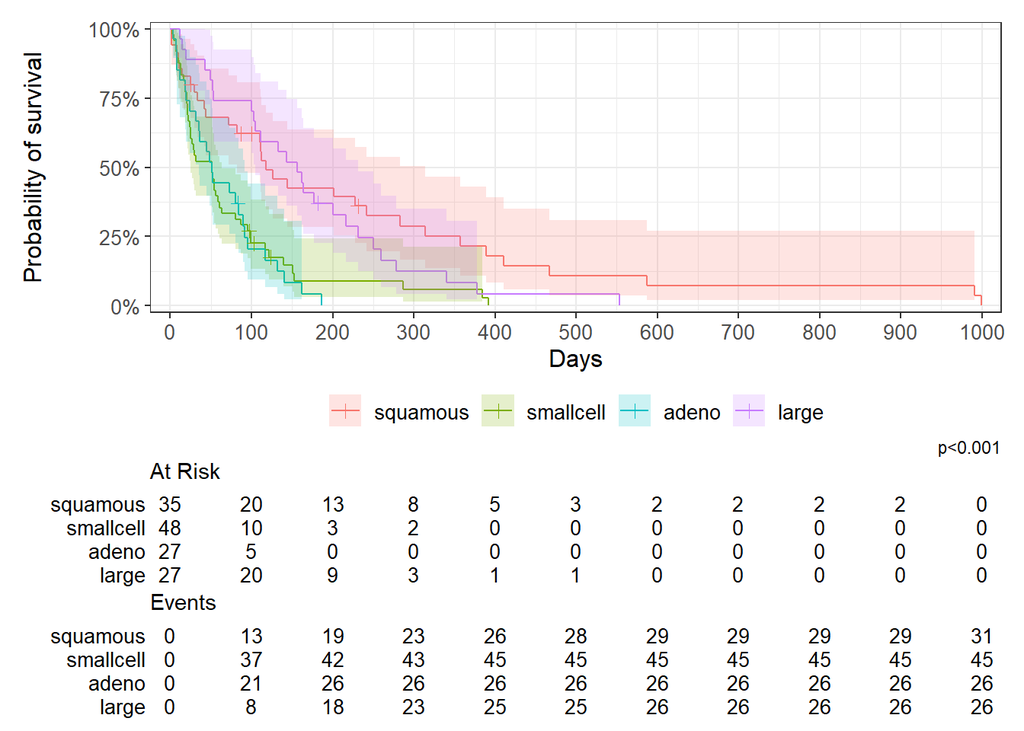

The above table is quite messy, so let’s facet the data into separate plots per cell type.

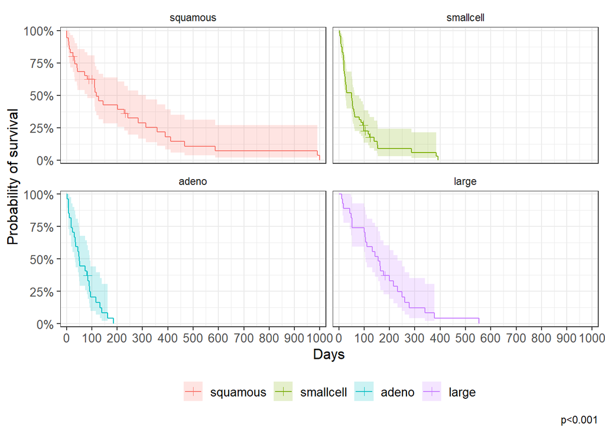

As one can see, there is a striking visual difference between cell types in regard to survival probability. For example, patients that have squamous cell cancer seem to unilaterally have better survival probability over time compared to patients with adenocarcinoma. But is the difference statistically significant? The first plot reports *p* <0.001, which would be highly significant, but let’s run a log-rank test separately.

```
Call:
survdiff(formula = Surv(time, status) ~ celltype, data = veteran_data_df)

                    N Observed Expected (O-E)^2/E (O-E)^2/V
celltype=squamous  35       31     47.7      5.82     10.53
celltype=smallcell 48       45     30.1      7.37     10.20
celltype=adeno     27       26     15.7      6.77      8.19
celltype=large     27       26     34.5      2.12      3.02

 Chisq= 25.4  on 3 degrees of freedom, p= 1e-05
```

The log-rank test actually returns *p* = 1e-05 (e.g., *p* = 0.00001). The result therefore is highly statistically significant. However, is the sample size truly large enough to provide enough statistical power to trust this significance result? We can use a Cox proportional hazards model to infer whether or not this data can provide conclusive evidence regarding power - if there is enough power, then the width of confidence intervals should be narrow.

We will use squamous carcinoma data as the reference point.

```
Call:
coxph(formula = Surv(time, status) ~ celltype, data = veteran_data_df)

  n= 137, number of events= 128

                    coef exp(coef) se(coef)     z Pr(>|z|)
celltypesmallcell 1.0013    2.7217   0.2535 3.950 7.83e-05 ***
celltypeadeno     1.1477    3.1510   0.2929 3.919 8.90e-05 ***
celltypelarge     0.2301    1.2588   0.2773 0.830    0.407
---
Signif. codes:  0 '***' 0.001 '**' 0.01 '*' 0.05 '.' 0.1 ' ' 1

                  exp(coef) exp(-coef) lower .95 upper .95
celltypesmallcell     2.722     0.3674     1.656     4.473
celltypeadeno         3.151     0.3174     1.775     5.594
celltypelarge         1.259     0.7944     0.731     2.168

Concordance= 0.608  (se = 0.028 )
Likelihood ratio test= 24.85  on 3 df,   p=2e-05
Wald test            = 24.09  on 3 df,   p=2e-05
Score (logrank) test = 25.51  on 3 df,   p=1e-05
```

## Differences by Treatment and Cell Type

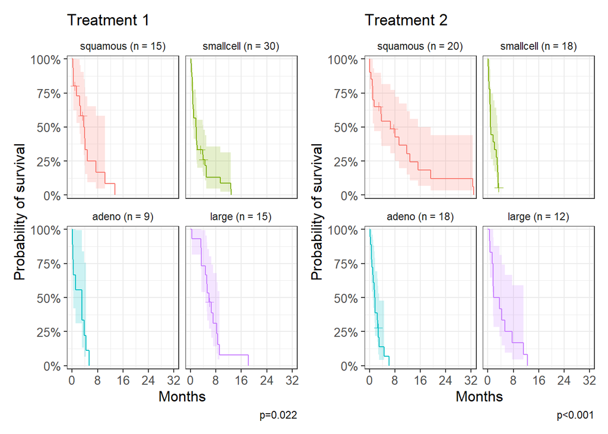

Figure 7: Comparison of survival probability across time between both treatment conditions. Treatment 1 cohort (n = 69) on the left, Treatment 2 cohort (n = 68) on the right.

Again, one can see there is a statistically significant difference between the cell types in regard to survival probability over time (as seen with the report p-values at the bottom of each graph) albeit with quite wide confidence intervals at times, but the information of interest is whether or not there is a significant difference within cell types by treatment condition (e.g., does treatment 1 result in better or worse outcomes for adenocarcinoma compared to treatment 2?).

For this, we can run a Cox regression model, and then create a forest plot using the results.

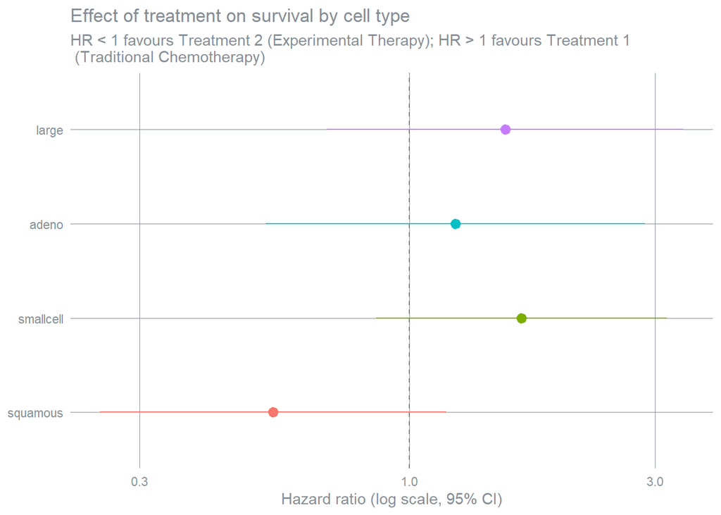

At first glance, one might want to infer that squamous cell carcinoma benefits from the experimental therapy whilst the other cancers do not. However, the long horizontal lines stretching out from the coloured hazard point denote the confidence intervals, which all cross the median (1) for the HR. This means the true value for each cell type may lie in the “no effect” point, and so we are forced to conclude that the data itself is inconclusive regarding the question of treatment efficacy on specific cell-types.

This isn’t entirely unexpected, the sample sizes per cell type group are quite small (n = 27 on the low end, n = 48 on the high end) which is only made smaller once dividing along treatment condition lines. This typically means that any confidence interval produced will be much wider, as the data produces low predictive power.

# Conclusion

We cannot conclusively state that the novel chemotherapy treatment significantly influences survival probability, either across the entire cohort or in specific cell types. There is some evidence to suggest that squamous cell carcinoma may benefit from the novel treatment, but said evidence is inconclusive with existing confidence intervals.

# Citations

Kalbfleisch, John D., and Ross L. Prentice. 1980. *The Statistical Analysis of Failure Time Data*. Wiley. https://doi.org/10.1002/9781118032985.

Kanchustambham, Venkatkiran, and Sanjeev Sharma. 2026. *Lung Adenocarcinoma*. StatPearls Publishing.

Terry M. Therneau, and Patricia M. Grambsch. 2000. *Modeling Survival Data: Extending the Cox Model*. Springer.

# IDE information for reproducibility

All analysis was conducted in RStudio 2026.08.2+200 “Yellow Yarrow” Release (1b2c764d96f951e5d3e80c05e095a53bdcde7c78, 2026-08-26) for windows Mozilla/5.0 (Windows NT 10.0; Win64; x64) AppleWebKit/537.36 (KHTML, like Gecko) RStudio/2026.08.2+200 Chrome/148.0.7778.280 Electron/42.7.1 Safari/537.36, Quarto 1.9.38